# MA415/615 Project One: U.S. Total Illegal Alien Apprehensions Analysis

Febuary 18, 2018

## Background

Based on CNN news, we realized that the US-Mexico broader apprehensions hit 17 years lowest in the first few months of the Trump administration. This phenomenon has been interpreted as "President Donald Trump's rhetoric and aggressive push to enforce immigration laws". Therefore, we want to analyze the data from the past to see whether this phenomenon had already existed before or it's really related to the new law as people saying.

## Datasets

- BP Apprehensions 2010.csv
- BP Apprehensions 2017.csv
- BP monthly summaries.csv

## Compare Apprehensions by Sectors

Q1: Tucson has highest appehensions in 2010, and Rio Grande Valley the highest in 2017. Has there been a change in maximum?

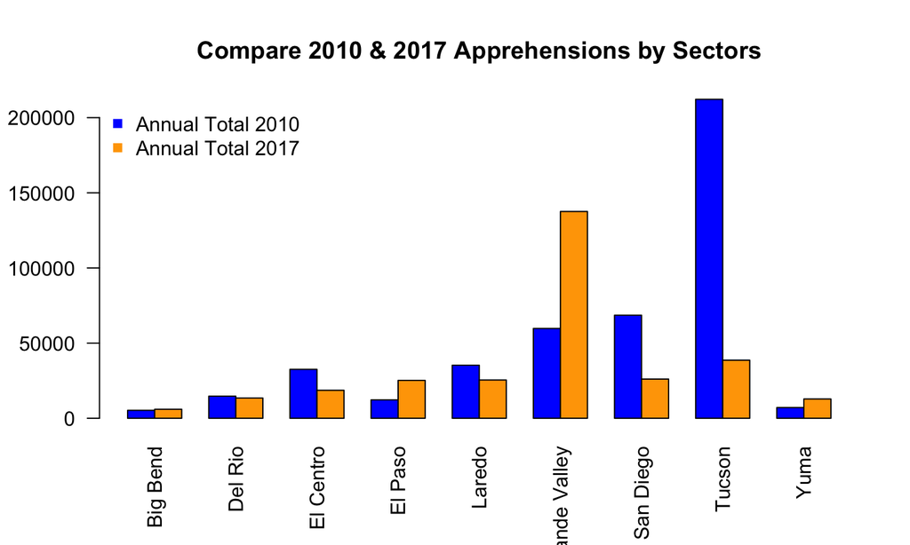

## Compare Apprehensions by Months

Q2: It seems Mar, Apr, and May has highest apprehensions in 2010, and Oct, Nov, and Dec do in 2017. Is our observation correct? Has the 3-month maximum changed?

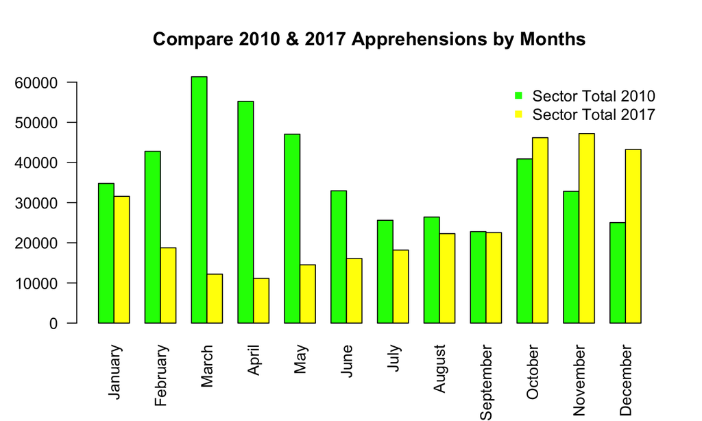

## Q1: Find the Maximum Sectors

By looking barplot and running code in R, we get the same result:

```r
#find the index of the sector that has most apprehensions in 2010
most_apprehensions_2010 <- match(max(B2010[1:9,13]), B2010[1:9,13])
#it is Tucson
rownames(B2010)[most_apprehensions_2010]
```

```
## [1] "Tucson"
```

```r
#find the index of the sector that has most apprehensions in 2017
most_apprehensions_2017 <- match(max(B2017[1:9,13]), B2017[1:9,13])
#it is Rio Grande Valley
rownames(B2017)[most_apprehensions_2017]
```

```
## [1] "Rio Grande Valley"
```

## Q1: Has Maximum Changed? Using Welch Two Sample t-test.

We have the following hypothesis:

\(H_{0}:\mu _{Tucson, 2010} - \mu _{RGV, 2017} = 0\) \(H_{a}:\mu _{Tucson, 2010} - \mu _{RGV, 2017} \neq 0\)

```r
#create the dataset for Tucson in 2010
B2010_Tuson <- B2010[most_apprehensions_2010,1:12]
#create the dataset for Rio Grande Valley in 2017
B2017_RGV <- B2017[most_apprehensions_2017,1:12]
```

## Q1: Has Maximum Changed? Using Welch Two Sample t-test.

```r
#test whether these two samples have same sample mean
t.test(B2010_Tuson, B2017_RGV)
```

```
##
##  Welch Two Sample t-test
##
## data:  B2010_Tuson and B2017_RGV
## t = 1.9547, df = 21.973, p-value = 0.06346
## alternative hypothesis: true difference in means is not equal to 0
## 95 percent confidence interval:
##   -379.5935 12819.5935
## sample estimates:
## mean of x mean of y
##   17683.5   11463.5
```

## Q1: Has Maximum Changed? Using Welch Two Sample t-test.

\(H_{0}:\mu _{Tucson, 2010} - \mu _{RGV, 2017} = 0\) \(H_{a}:\mu _{Tucson, 2010} - \mu _{RGV, 2017} \neq 0\)

t = 1.9547, df = 21.973, p-value = 0.06346

Because p-value = 0.06346 > 0.05, we fail to reject the null hypothesis at significance level of 5%, and conclude that there is NO significant difference between the means of the highest sector apprenhensions in 2010 and 2017

## Q2: Find the three Months with Most Apprehensions

Our observation from barplot is correct

```r
#find the three months that has the most apprehensions in 2010
most_3m_apprehensions_2010 <- order(B2010[10,1:12], decreasing = TRUE)[1:3]
#they are March, April, and May
colnames(B2010)[most_3m_apprehensions_2010]
```

```
## [1] "March" "April" "May"
```

```r
#find the three months that has the most apprehensions in 2017
most_3m_apprehensions_2017 <- order(B2017[10,1:12], decreasing = TRUE)[1:3]
#they are November, October, and December
colnames(B2017)[most_3m_apprehensions_2017]
```

```
## [1] "November" "October"  "December"
```

## Q2: Has 3-Month Maximums Changed? Using Welch Two Sample t-test.

We have the following hypothesis:

\(H_{0}:\mu _{3 months, 2010} - \mu _{3 months, 2017} = 0\) \(H_{a}:\mu _{3 months, 2010} - \mu _{3 months, 2017} \neq 0\)

```r
#create the dataset for March, April, and May in 2010
B2010_3m <- B2010[most_3m_apprehensions_2010,1:12]
#create the dataset for November, October, and December in 2017
B2017_3m <- B2017[most_3m_apprehensions_2017,1:12]
```

## Q2: Has 3-Month Maximum Changed? Using Welch Two Sample t-test.

```r
#test whether these two samples have same sample mean
t.test(B2010_3m, B2017_3m)
```

```
##
##  Welch Two Sample t-test
##
## data:  B2010_3m and B2017_3m
## t = -5.9857, df = 11.05, p-value = 8.944e-05
## alternative hypothesis: true difference in means is not equal to 0
## 95 percent confidence interval:
##  -31591.20 -14611.46
## sample estimates:
## mean of x mean of y
##   2225.00  25326.33
```

## Q2: Has 3-Month Maximum Changed? Using Welch Two Sample t-test.

\(H_{0}:\mu _{3 months, 2010} - \mu _{3 months, 2017} = 0\) \(H_{a}:\mu _{3 months, 2010} - \mu _{3 months, 2017} \neq 0\)

## Time Series Chart

Decreasing trend

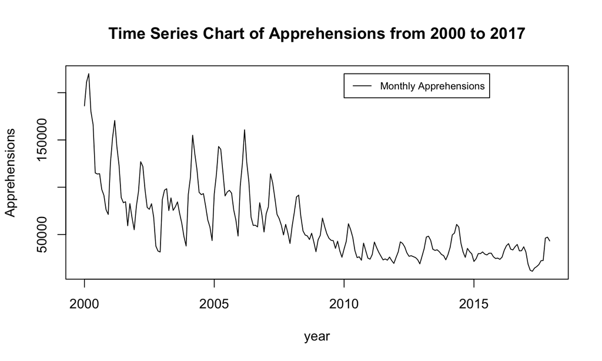

## Time Series Chart

Annual Average shown by Segments

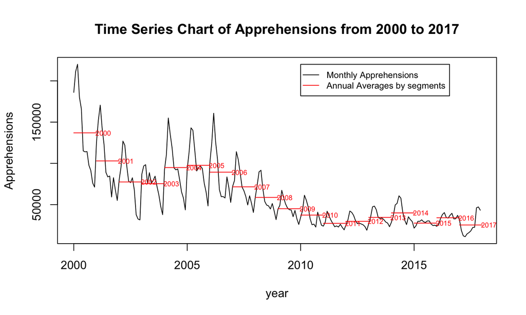

## Time Series Chart

Changed to Points

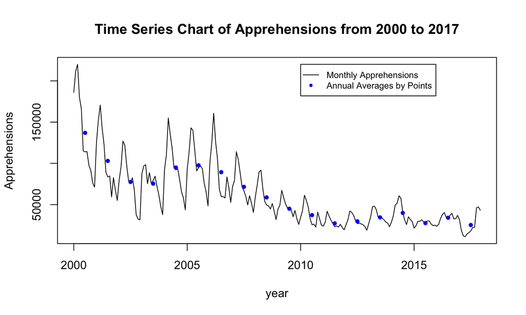

## Time Series Chart

Change to Points and Line

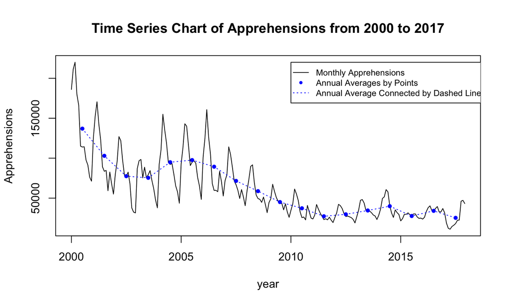

## Time Series Chart

All together

[figure not shown]

## Time Series Chart

By looking at the Time Series Chart, we know that the number of monthly apprehensions in US is decreasing through years and reached a lowest point in lastest 17 years in 2017.

[figure not shown]